# STATS 607 - LECTURE 4

# Regular Expressions

Regular expressions (called REs, or regexes, or regex patterns) is a highly specialized programming language embedded inside Python and made available through the 're' module. With it, you can specify a set of rules to obtain matching strings. The following examples cover some of the most important functions available in Python.

```python
import re # re stands for regular expressions.
```

```python
line = "This class is really fun!"
```

```python
matchObj = re.match(r'class', line) # Match matches a re to the beginning of the string.
print(matchObj)
print(bool(matchObj))
```

```
None
False
```

```python
matchObj = re.match(r'This', line)
print(matchObj)
```

```
<_sre.SRE_Match object; span=(0, 4), match='This'>
```

```python
matchObj = re.match(r'this', line) # Notice that the match is case-sensitive.
print(matchObj)
```

```
None
```

```python
matchObj = re.match(r'this', line, re.I) # You can supply a flag to set different options.
print(matchObj)
```

```
<_sre.SRE_Match object; span=(0, 4), match='This'>
```

```python
matchObj = re.match(r'This (.*) is (.*) .*', line) # Grouping is done with '()'
```

```python
print("matchObj.group() : ", matchObj.group())
print("matchObj.group(1) : ", matchObj.group(1))
print("matchObj.group(2) : ", matchObj.group(2))
print("matchObj.groups() : ", matchObj.groups())
```

```
matchObj.group() :  This class is really fun!
matchObj.group(1) :  class
matchObj.group(2) :  really
matchObj.groups() :  ('class', 'really')
```

```python
line = "Humm... This class is really really fun!"
matchObj = re.match(r'^(h.*) is (.*) (.*)$', line, re.I)
```

```python
print("matchObj.group() : ", matchObj.group())
print("matchObj.group(1) : ", matchObj.group(1))
print("matchObj.group(2) : ", matchObj.group(2))
print("matchObj.group(3) : ", matchObj.group(3))
```

```
matchObj.group() :  Humm... This class is really really fun!
matchObj.group(1) :  Humm... This class
matchObj.group(2) :  really really
matchObj.group(3) :  fun!
```

```python
line = "Humm... This class is really really fun!"
matchObj = re.match(r'^(h.*) is ([^\s]*) (.*)$', line, re.I)
```

```python
print("matchObj.group() : ", matchObj.group())
print("matchObj.group(1) : ", matchObj.group(1))
print("matchObj.group(2) : ", matchObj.group(2))
print("matchObj.group(3) : ", matchObj.group(3))
```

```
matchObj.group() :  Humm... This class is really really fun!
matchObj.group(1) :  Humm... This class
matchObj.group(2) :  really
matchObj.group(3) :  really fun!
```

```python
line = "Humm... This class is really really fun!"
matchObj = re.match(r'^(h.*) is ([^\s]*)$ (.*)', line, re.I)
```

```python
print("matchObj.group() : ", matchObj.group())
print("matchObj.group(1) : ", matchObj.group(1))
print("matchObj.group(2) : ", matchObj.group(2))
print("matchObj.group(3) : ", matchObj.group(3))
```

```
---------------------------------------------------------------------------
AttributeError                            Traceback (most recent call last)
<ipython-input-38-b03fb2cfdc5e> in <module>()
----> 1 print("matchObj.group() : ", matchObj.group())
      2 print("matchObj.group(1) : ", matchObj.group(1))
      3 print("matchObj.group(2) : ", matchObj.group(2))
      4 print("matchObj.group(3) : ", matchObj.group(3))

AttributeError: 'NoneType' object has no attribute 'group'
```

```python
matchObj = re.search(r'Class', line, re.I) # You can also match anywhere in the string.
print(matchObj.group())
```

```
class
```

```python
line = "This class is really really fun!" # You can make substitutions of matched strings.
re.sub(r'really', 'not' , line)
```

```
'This class is not not fun!'
```

```python
re.sub(r'really', 'not' , line, count=1)
```

```
'This class is not really fun!'
```

See below for more examples with additional relevant regular expression operators. Please note the goal here is to exemplify. It is not necessarily the best and certainly, it is not the only way of going about it.

```python
line = "321-233-1234 # This is a phone number!"
matchObj = re.match(r'[0-9]*\-[0-9]*\-[0-9]*', line) # Recovering only the telephone number.
print("matchObj.group() : ", matchObj.group())
```

```
matchObj.group() :  321-233-1234
```

```python
rePattern = re.compile(r'[0-9]*\-[0-9]*\-[0-9]*') # Use the compile function if you are going to use the re several times.
lines = ["321-233-1234 # This is a phone number!", '812-345-7654 Something', '123-456-7890']
[rePattern.match(line).group() for line in lines]
```

```
['321-233-1234', '812-345-7654', '123-456-7890']
```

```python
line = "321-233-1234 # This is a phone number!"
matchObj = re.match(r'([0-9]{3})\-[0-9]{3}\-[0-9]{4}', line) # Using additional grouping.
print("matchObj.group() : ", matchObj.group())
print("matchObj.group(1) : ", matchObj.group(1))
```

```
matchObj.group() :  321-233-1234
matchObj.group(1) :  321
```

```python
line = "321-233-1234 # This is a phone number!"
matchObj = re.search(r'[^0-9\-]+', line) # Now removing the telephone numbers.
print("matchObj.group() : ", matchObj.group())
```

```
matchObj.group() :   # This is a phone number!
```

```python
line = "321-233-1234 # This is a phone number!" # Yet another way but this time using the 'sub' function.
re.sub(r'[0-9\-]+','', line)
```

```
' # This is a phone number!'
```

```python
line = 'tea for too'
line.replace('too', 'two') # You can use string replacement numbers for simple operations.
```

```
'tea for two'
```

Here are a few of the most important regular expression operators:

```python
^ : Matches beginning of line.
$ : Matches end of line.
. : Matches any single character except newline. Using m option allows it to match newline as well.
[...] : Matches any single character in brackets.
[^...] : Matches any single character not in brackets.
re* : Matches 0 or more occurrences of preceding expression.
re+ : Matches 1 or more occurrence of preceding expression.
re? : Matches 0 or 1 occurrence of preceding expression.
re{n} : Matches exactly n number of occurrences of preceding expression.
re{n,} : Matches n or more occurrences of preceding expression.
re{n, m} : Matches at least n and at most m occurrences of preceding expression.
```

# Mathematics

```python
import math
```

```python
print(dir(math)) # Lets see what we have available on the math module.
```

```
['__doc__', '__file__', '__loader__', '__name__', '__package__', '__spec__', 'acos', 'acosh', 'asin', 'asinh', 'atan', 'atan2', 'atanh', 'ceil', 'copysign', 'cos', 'cosh', 'degrees', 'e', 'erf', 'erfc', 'exp', 'expm1', 'fabs', 'factorial', 'floor', 'fmod', 'frexp', 'fsum', 'gamma', 'gcd', 'hypot', '…
```

```python
math.sin(pi/2) # Why does this return an error?
```

```
---------------------------------------------------------------------------
NameError                                 Traceback (most recent call last)
<ipython-input-55-2aee301f94d8> in <module>()
----> 1 math.sin(pi/2) # Why does this return an error?

NameError: name 'pi' is not defined
```

```python
math.sin(math.pi/2) # Here is how to solve the previous problem.
```

```
1.0
```

```python
math.log2(32) # The math module also provides other bases.
```

```
5.0
```

```python
math.factorial(4) # This time around, lets use the factorial function defined in 'math'.
```

```
24
```

```python
math.pow(2,5) # This is another way of writing power.
```

```
32.0
```

```python
import random
```

```python
print(dir(random))
```

```
['BPF', 'LOG4', 'NV_MAGICCONST', 'RECIP_BPF', 'Random', 'SG_MAGICCONST', 'SystemRandom', 'TWOPI', '_BuiltinMethodType', '_MethodType', '_Sequence', '_Set', '__all__', '__builtins__', '__cached__', '__doc__', '__file__', '__loader__', '__name__', '__package__', '__spec__', '_acos', '_bisect', '_ceil'…
```

```python
random.choice(['A','random', 'word', 'from', 'this', 'list']) # A random word from the list.
```

```
'from'
```

```python
random.choice('A random word from this string') # What is the difference from the above?
```

```
'i'
```

```python
?random.choices

Signature: random.choices(population, weights=None, *, cum_weights=None, k=1)
Docstring:
Return a k sized list of population elements chosen with replacement.

If the relative weights or cumulative weights are not specified,
the selections are made with equal probability.
File:      /Applications/anaconda3/lib/python3.6/random.py
Type:      method
```

```python
random.choices(range(10), k=5) # Random sample with replacement.
```

```
[8, 8, 9, 5, 5]
```

```python
random.random() # A random number in the interval [0,1)
```

```
0.6495682888895576
```

```python
random.gauss(2,0.5) # A random number from a gaussian distribution (mean, std)
```

```
2.839040691348475
```

```python
numbersFromNormalDistr = [round(random.gauss(2,0.5),2) for i in range(1000)]
```

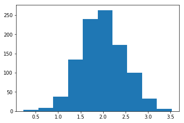

```python
%matplotlib inline
from matplotlib import pyplot as plt
plt.hist(numbersFromNormalDistr)
```

```python
import statistics
```

```python
print(dir(statistics))
```

```
['Decimal', 'Fraction', 'StatisticsError', '__all__', '__builtins__', '__cached__', '__doc__', '__file__', '__loader__', '__name__', '__package__', '__spec__', '_coerce', '_convert', '_counts', '_exact_ratio', '_fail_neg', '_find_lteq', '_find_rteq', '_isfinite', '_ss', '_sum', 'bisect_left', 'bisec…
```

Lets use just a few of the most common descriptive statistical functions.

```python
print(statistics.mean(numbersFromNormalDistr))
print(statistics.median(numbersFromNormalDistr))
print(statistics.variance(numbersFromNormalDistr))
print(math.sqrt(statistics.variance(numbersFromNormalDistr)))
```

```
1.9773
1.97
0.2416835935935936
0.49161325612069656
```

# Dates

```python
from datetime import datetime, date, time
```

```python
dt = datetime(2018,10,29,20,30,21) # Create object datetime.
```

```python
dt.day # Retrieves the day from datetime object.
```

```
29
```

```python
dt.minute # Retrieves the minute from datetime object.
```

```
30
```

```python
dt.date() # Retrieves just the date.
```

```
datetime.date(2018, 10, 29)
```

```python
dt.time() # Retrieves just the time.
```

```
datetime.time(20, 30, 21)
```

```python
dt.strftime('%m/%d/%Y %H:%M') # Formats a datetime object as a string.
```

```
'10/29/2018 20:30'
```

```python
datetime.strptime('01012009','%m%d%Y') # Converts string to datetime object.
```

```
datetime.datetime(2009, 1, 1, 0, 0)
```

```python
currDay = date.today() # Obtain today's date.
currDay
```

```
datetime.date(2018, 9, 17)
```

```python
currDay.strftime("%m-%d-%y. %d %b %Y is a %A on the %d day of %B.") # Formats a datetime as a string.
```

```
'09-17-18. 17 Sep 2018 is a Monday on the 17 day of September.'
```

We can also do numerical operations on dates, such as the subtraction. Lets see how much time you have to solve and deliver the first assignment.

```python
firstAssignDate = date(2018,9,19)
firstDeliverDate = date(2018,9,26)
time2Solve = firstDeliverDate - firstAssignDate
```

```python
print('You have',time2Solve.days,'days to solve the exercise!')
```

```
You have 7 days to solve the exercise!
```

# Performance measurement

```python
from timeit import Timer
```

The first argument of Timer is comprised of the statements you will timing. The second argument is the setup. The 'timeit' function has a default number of times it will run the statements. Here, we will specify the number of time we want the statements to be executed.

```python
Timer('t=a; a=b; b=t', 'a=1; b=2').timeit(int(10e6))
```

```
0.32726552498934325
```

```python
Timer('a,b = b,a', 'a=1; b=2').timeit(int(10e6))
```

```
0.2824283890076913
```